# Preprocesamiento

Master de Big Data

José Tomás Palma Méndez

5 de February de 2025

# 1 Introducción

En esta sesión vamos a ver los aspectos básicos y herramientas que nos va a permitir desarrollar técnicas de preprocesamiento de datos en R.

**Paquetes necesarios:** `foreign`, `car`, `Hmisc`, `VIM`, `mice`, `caret`, `smotefamily` y `ROSE`.

# 2 Valores especiales

Al igual que en la mayoría de los lenguajes de programación en R también podemos encontrar valores especiales que indican alguna excepción respecto a los valores normales. Estos valores son: `NA`, `NULL`, $\pm$`InF` y `NaN`.

- `NA` (Not available). Esté valor se utiliza para indicar que el dato en cuestión no está disponible. Todas las operaciones básicas en R pueden manipular valores `NA` sin provocar errores y la mayoría devolverán valores `NA` si uno de los argumentos es `NA`. Para detectar valores NA se puede utilizar la función `is.na()`.
- `NULL`. Se puede considerar como el conjunto vacío. `NULL` no tiene asociada ninguna clases y tiene longitud 0 y, por lo tanto, no ocupa espacio en el vector. Para detectar valores NULL se puede utilizar la función `is.null()`.
- `Inf`. Este valor se utiliza para representar el `infinito` y solo esta asociado a variables de tipo numérico. Técnicamente, `Inf` es un valor numérico válido que es el resultado de operaciones como una división por cero. Por lo tanto, operaciones y comparaciones entre `Inf` y otros valores numéricos son perfectamente válidas. Las funciones `is.infinite()` y `is.finite()` nos pueden ayudar a detectar este tipo de valores.
- `NaN`. Se utiliza para representar valores desconocidos como resultado de alguna operación (`0/0`, `Inf-Inf` y `Inf/Inf`), pero de los que se tiene la seguridad de que no son números. La operaciones que implican un `NaN` dan como resultado un `NaN`. La función `is.NaN()` se puede usar para detectar `NaN`.

**Ejercicio 1:**

Teniendo en cuenta las anteriores definiciones, intenta descubrir el resultado de las siguientes operaciones y porqué se produce dicho resultado.

[output not shown]

Ademas de las funciones `is.` que hemos visto, `R` nos ofrece otras muchas funciones para identificar el tipo de una variable: `is.numeric()`, `is.character()`, `is.complex()`, `is.data.frame()`, etc. Consulta la ayuda de `R` y examina todas las funciones de este tipo.

# 3 Lectura de datos

`R` es capaz de leer y procesar datos en multitud de formatos. Aquí nos vamos a centrar en datos en forma de tabla y en formato texto (la mayoría de las aplicaciones pueden exportar a este formato). A groso modo podemos decir que un dataset es técnicamente correcto cuando:

- está almacenado en un `data.frame` con los nombres adecuados para las columnas (atributos), y
- cada columna es del tipo de dato acorde con el domino de la variable que representa. Por ejemplo, los datos categóricos deben estar definidos como `factor` y los números como `numeric` o `intenger`.

En tareas de clasificación, hay que asegurarse de que la variable que indica la clase esté definida como `factor`. Esto se debe a que hay casos en que las clases se etiquetan con números $(0, 1, ..)$. Al importar esta información, entiende que la variable es numérica, y cuando intentemos crear modelos de clasificación, puede que `R` genere modelos de regresión.

**Ejercicio 2:**

Abre con algún editor el fichero `hepatitis.csv` que podrás encontrar en la carpeta **recursos** del aula virtual.

1. ¿Cuáles crees que deben ser los tipos asociados a cada columna?
2. ¿Existen valores desconocidos? ¿Cómo están representados?
3. ¿Qué información crees que falta?

Las función más básicas que ofrece `R` para leer datos son:

| Función | Descripción |
| --- | --- |
| `read.csv()` | para valores separados por comas con el punto para separar decimales |
| `read.csv2()` | para valores separados por puntos y comas con la coma para separar decimales |
| `read.delim()` | para valores separados por tabuladores con el punto para separar decimales |
| `read.delim2()` | para valores separados por tabuladores con la coma para separar decimales |
| `read.fwf()` | para columnas con un tamaño predeterminado |

Todas estas funciones aceptan entre otros los siguientes parámetros:

| Parámetro | Descripción |
| --- | --- |
| `header` | ¿La primera fila contiene los nombres de las columnas? |
| `col.names` | Array de strings con los nombres de las columnas |
| `na.string` | Array para indicar cómo se representan los valores ausentes |
| `colClasess` | Array que indica el tipo de cada columna |
| `stringsAsFactors` | Si es `TRUE` indica que las columnas con strings se convierten a `factors` |
| `sep` | Separador de columnas (sólo para `read.fwf()`) |

Todos estos parámetros también pueden ser modificados a través de la interfaz que ofrece `RStudio`.

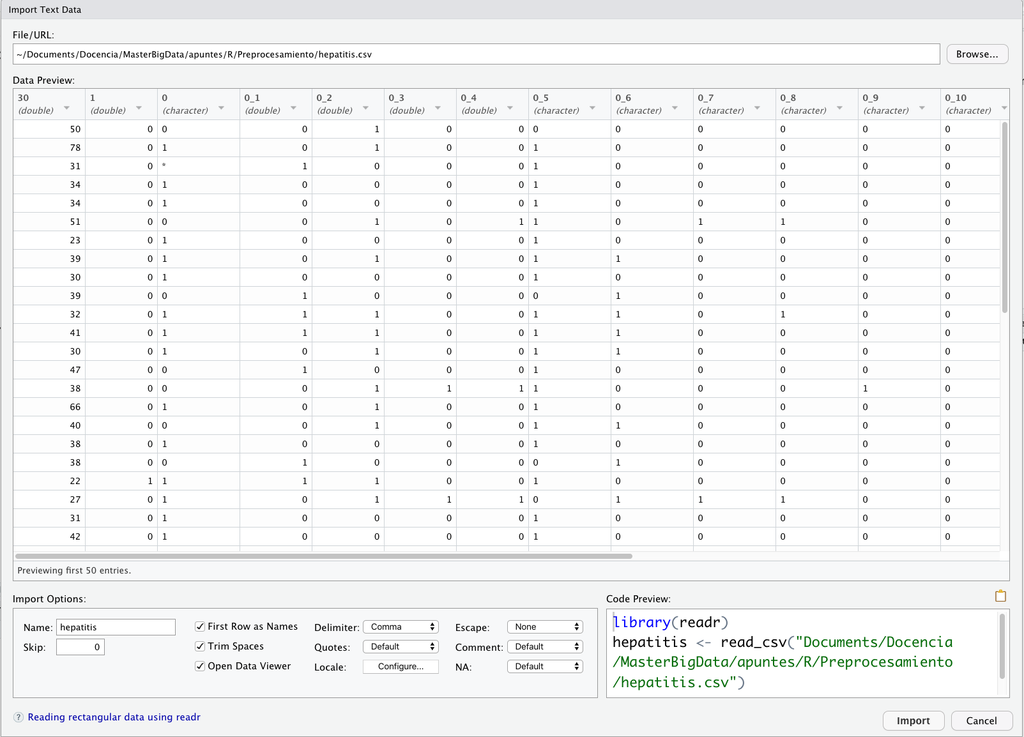

Interfaz para importación de datos en `RStudio`

**Otros paquetes para la importación de datos:** `foreign`, `readr`, `vroom`, `rio`, entre otros. Estos paquetes te ofrecen funciones más eficientes para grandes conjuntos de datos y que abarcan una gran variedad de formatos deferentes.

Cuando importes unos datos con algunas de estas funciones, examínalos primero con funciones como `head()`, `str()` y `summary()`.

**Ejercicio 3:**

Importa el fichero `hepatitis.csv` desde `RStudio`, sin modificar los parámetros.

1. Ejecuta el comando `str(hepatitis)` y copia el resultado ¿Qué anomalías encuentras? Enuméralas. 2.La función `complete.cases()` nos indica el número de filas completas que hay en el `data.frame`. Ejecútala sobre el conjunto de datos importados ¿Es el resultado esperado?
2. ¿Cómo podríamos con una sólo línea de código sustituir todos los valores que indican un dato no presente por un `NA`?
3. Prueba a volver a cargar los datos desde RStudio utilizando correctamente le parámetro `na.strings`. Una vez importados los datos ejecuta el comando `str()` y compara los resultados con el caso anterior ¿Ves alguna anomalía?.
4. ¿Cómo podríamos calcular en una sólo línea de código el número de filas que tiene algún valor desconocido?

En el Ejercicio 3 hemos aprendido a identificar de forma correcta los valores ausentes al importar datos en `R`. El siguiente paso consiste en nombrar de forma correcta las columnas. Este paso nos lo podemos saltar en el caso que el conjunto de datos incluya dichos nombres en la primera línea y colocando el parámetro `header=TRUE` al llamar a la función . En nuestro caso, el nombre de cada una de las columnas aparece como información adicional y deberían nombrarse como: EDAD, SEXO, ESTEROIDES, ANTIVIRALES, FATIGA, MALAISE, ANOREXIA, HIGgrande, HIGfirme, BAZOpalpa, ARANIASvac., ASCITIS, VARICES, BILIRRUBINA, FOSFATOalc, SGOT, ALBUMINA, PROTIME, HISTIOLOGIA y PRONOSTICO. Para que las columnas de nuestro conjunto de datos adopten estos nombres debemos hacer:

```r
atributos <- c(
  "EDAD", "SEXO", "ESTEROIDES", "ANTIVIRALES", "FATIGA", "MALAISE",
  "ANOREXIA", "HIGgrande", "HIGfirme", "BAZOpalpa", "ARANIASvac",
  "ASCITIS", "VARICES", "BILIRRUBINA", "FOSFATOalc", "SGOT",
  "ALBUMINA", "PROTIME", "HISTIOLOGIA", "PRONOSTICO"
)
colnames(hepatitis) <- atributos
```

# 4 Conversión de tipos

Una vez interpretados de forma correcta los valores ausentes y haberle dado nombre a las columnas. El siguiente paso en el procesamiento de datos consiste en definir los tipos de datos adecuados para cada columna. Esto lo podemos hacer mediante las funciones con el prefijo `as.` de `R`. Por ejemplo, para convertir una variable cualquiera, `var`, a variable real, sólo deberíamos ejecutar el siguiente comando:

```r
var <- as.numeric(var)
```

En nuestro caso, el atributo `ANTIVIRALES` es una variable booleana y la conversión la podríamos hacer con la siguiente instrucción:

```r
hepatitis$ANTIVIRALES <- as.logical(hepatitis$ANTIVIRALES)
```

Puedes comprobar con la función `str()` el efecto que ha producido la instrucción anterior.

```r
str(hepatitis)
```

```
## 'data.frame':    155 obs. of  20 variables:
##  $ EDAD       : int  30 50 78 31 34 34 51 23 39 30 ...
##  $ SEXO       : int  1 0 0 0 0 0 0 0 0 0 ...
##  $ ESTEROIDES : int  0 0 1 NA 1 1 0 1 1 1 ...
##  $ ANTIVIRALES: logi  FALSE FALSE FALSE TRUE FALSE FALSE ...
##  $ FATIGA     : int  0 1 1 0 0 0 1 0 1 0 ...
##  $ MALAISE    : int  0 0 0 0 0 0 0 0 0 0 ...
##  $ ANOREXIA   : int  0 0 0 0 0 0 1 0 0 0 ...
##  $ HIGgrande  : int  0 0 1 1 1 1 1 1 1 1 ...
##  $ HIGfirme   : int  0 0 0 0 0 0 0 0 1 0 ...
##  $ BAZOpalpa  : int  0 0 0 0 0 0 1 0 0 0 ...
##  $ ARANIASvac : int  0 0 0 0 0 0 1 0 0 0 ...
##  $ ASCITIS    : int  0 0 0 0 0 0 0 0 0 0 ...
##  $ VARICES    : int  0 0 0 0 0 0 0 0 0 0 ...
##  $ BILIRRUBINA: num  1 0.9 0.7 0.7 1 0.9 NA 1 0.7 1 ...
##  $ FOSFATOalc : int  85 135 96 46 NA 95 NA NA NA NA ...
##  $ SGOT       : int  18 42 32 52 200 28 NA NA 48 120 ...
##  $ ALBUMINA   : num  4 3.5 4 4 4 4 NA NA 4.4 3.9 ...
##  $ PROTIME    : int  NA NA NA 80 NA 75 NA NA NA NA ...
##  $ HISTIOLOGIA: int  0 0 0 0 0 0 0 0 0 0 ...
##  $ PRONOSTICO : int  1 1 1 1 1 1 0 1 1 1 ...
```

**Ejercicio 4:** Realiza las conversiones de tipo indicadas en la siguiente tabla.

| Tipo | Variables |
| --- | --- |
| `numeric` | BILIRRUBINA y ALBUMINA |
| `integer` | EDAD, SGOT, FOSFATOalc y PROTIME |
| `logical` | HISTIOLOGÍA y **desde** ESTEROIDES **hasta** VARICES |

Comprueba con el comando `str(hepatitis)`que los tipos na sido asignados correctamente.

Llegados a este punto, nos queda por tratar de forma correcta los atributos originales. En este caso obsérvese que el atributo PRONOSTICO está definido como entero y, por lo tanto, si se intenta aplicar técnicas de clasificación, o bien no se podrán realizar o se construirá un modelo de regresión al estar definido dicho atributo como entero. En este caso bastaría con utilizar la función `as.factor()` sobre dicha columna.

Sin embargo, en estos casos sería más interesante que los elementos de la enumeración fuesen más informativos. En nuestro caso, sería deseable cambiar el 0 y el 1 por FALLECE Y VIVE, respectivamente. Esta recodificación de etiquetas se puede hacer utilizando la función `Recode()` del paquete `car`, de la siguiente forma:

```r
library(car)
hepatitis$PRONOSTICO <- as.factor(Recode(
  hepatitis$PRONOSTICO,
  "0 = 'FALLECE'; 1 = 'VIVE'"
))
```

La función `recode()` también permite asignar una misma etiqueta a varios valores. Por ejemplo, la siguiente instrucción

```r
recode(outcome, "c(1:3) = 'NORMAL ; 0 = 'ANORMAL'")
```

recodificaría los valores del 1 al 3 con la etiqueta NORMAL y el valor 0 con la de ANORMAL.

**Ejercicio 5:**

Transforma el atributo SEXO en un factor y asigna al 1 la etiqueta MASCULINO y al 0 la etiqueta FEMENINO.

Una vez hechas las transformaciones, nuestro conjunto de datos quedaría estructurado de la siguiente forma:

```r
str(hepatitis)
```

```
## 'data.frame':    155 obs. of  20 variables:
##  $ EDAD       : int  30 50 78 31 34 34 51 23 39 30 ...
##  $ SEXO       : Factor w/ 2 levels "FEMENINO","MASCULINO": 2 1 1 1 1 1 1 1 1 1 ...
##  $ ESTEROIDES : logi  FALSE FALSE TRUE NA TRUE TRUE ...
##  $ ANTIVIRALES: logi  FALSE FALSE FALSE TRUE FALSE FALSE ...
##  $ FATIGA     : logi  FALSE TRUE TRUE FALSE FALSE FALSE ...
##  $ MALAISE    : logi  FALSE FALSE FALSE FALSE FALSE FALSE ...
##  $ ANOREXIA   : logi  FALSE FALSE FALSE FALSE FALSE FALSE ...
##  $ HIGgrande  : logi  FALSE FALSE TRUE TRUE TRUE TRUE ...
##  $ HIGfirme   : logi  FALSE FALSE FALSE FALSE FALSE FALSE ...
##  $ BAZOpalpa  : logi  FALSE FALSE FALSE FALSE FALSE FALSE ...
##  $ ARANIASvac : logi  FALSE FALSE FALSE FALSE FALSE FALSE ...
##  $ ASCITIS    : logi  FALSE FALSE FALSE FALSE FALSE FALSE ...
##  $ VARICES    : logi  FALSE FALSE FALSE FALSE FALSE FALSE ...
##  $ BILIRRUBINA: num  1 0.9 0.7 0.7 1 0.9 NA 1 0.7 1 ...
##  $ FOSFATOalc : int  85 135 96 46 NA 95 NA NA NA NA ...
##  $ SGOT       : int  18 42 32 52 200 28 NA NA 48 120 ...
##  $ ALBUMINA   : num  4 3.5 4 4 4 4 NA NA 4.4 3.9 ...
##  $ PROTIME    : int  NA NA NA 80 NA 75 NA NA NA NA ...
##  $ HISTIOLOGIA: logi  FALSE FALSE FALSE FALSE FALSE FALSE ...
##  $ PRONOSTICO : Factor w/ 2 levels "FALLECE","VIVE": 2 2 2 2 2 2 1 2 2 2 ...
```

```r
datatable(hepatitis, options = list(
  deferRender = F,
  columnDefs = list(list(className = "dt-center", targets = 5)),
  scrollY = TRUE, scroller = TRUE, scrollX = FALSE,
  pageLength = 10
))
```

|  | EDAD | SEXO | ESTEROIDES | ANTIVIRALES | FATIGA | MALAISE | ANOREXIA | HIGgrande | HIGfirme | BAZOpalpa | ARANIASvac | ASCITIS | VARICES | BILIRRUBINA | FOSFATOalc | SGOT | ALBUMINA | PROTIME | HISTIOLOGIA | PRONOSTICO |
| --- | --- | --- | --- | --- | --- | --- | --- | --- | --- | --- | --- | --- | --- | --- | --- | --- | --- | --- | --- | --- |
| 1 | 30 | MASCULINO | False | False | False | False | False | False | False | False | False | False | False | 1 | 85 | 18 | 4 |  | False | VIVE |
| 2 | 50 | FEMENINO | False | False | True | False | False | False | False | False | False | False | False | 0.9 | 135 | 42 | 3.5 |  | False | VIVE |
| 3 | 78 | FEMENINO | True | False | True | False | False | True | False | False | False | False | False | 0.7 | 96 | 32 | 4 |  | False | VIVE |
| 4 | 31 | FEMENINO |  | True | False | False | False | True | False | False | False | False | False | 0.7 | 46 | 52 | 4 | 80 | False | VIVE |
| 5 | 34 | FEMENINO | True | False | False | False | False | True | False | False | False | False | False | 1 |  | 200 | 4 |  | False | VIVE |
| 6 | 34 | FEMENINO | True | False | False | False | False | True | False | False | False | False | False | 0.9 | 95 | 28 | 4 | 75 | False | VIVE |
| 7 | 51 | FEMENINO | False | False | True | False | True | True | False | True | True | False | False |  |  |  |  |  | False | FALLECE |
| 8 | 23 | FEMENINO | True | False | False | False | False | True | False | False | False | False | False | 1 |  |  |  |  | False | VIVE |
| 9 | 39 | FEMENINO | True | False | True | False | False | True | True | False | False | False | False | 0.7 |  | 48 | 4.4 |  | False | VIVE |
| 10 | 30 | FEMENINO | True | False | False | False | False | True | False | False | False | False | False | 1 |  | 120 | 3.9 |  | False | VIVE |

[output cut: 145 more lines]

# 5 Análisis de valores ausentes

Antes de empezar a imputar los valores ausentes habría que estudiar la distribución de los mismo. Una forma de verlo fácilmente utilizando la función `aggr()` del paquete `VIM`.

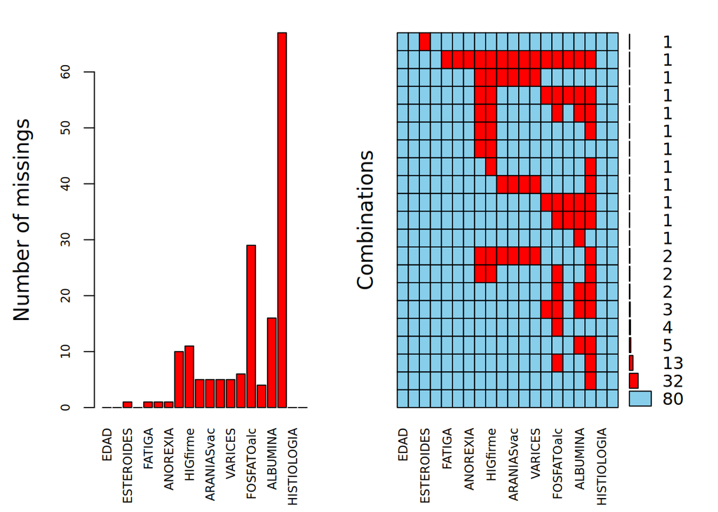

```r
library(VIM)
aggr(hepatitis, numbers = TRUE, prop = FALSE, cex.axis = 0.7)
```

Otra función útil para analizar la distribución de valores junto con la información sobre el número de valores ausentes junto con la distribución de los mismos es la función `describe()` del paquete `Hmisc`.

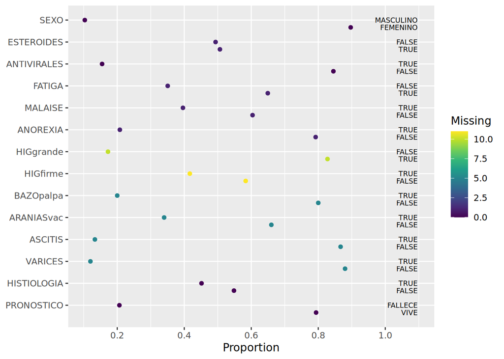

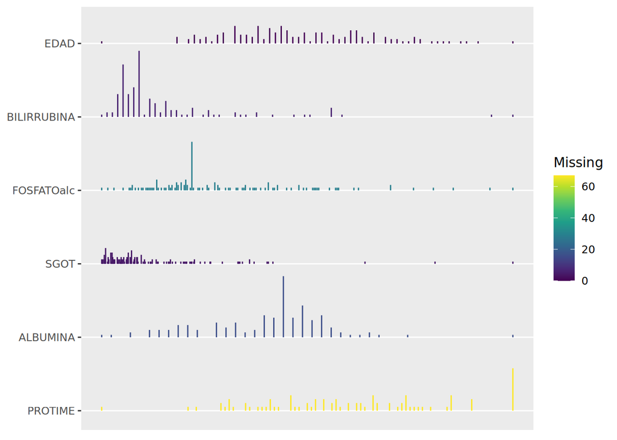

```r
library(Hmisc)
hepatitis.describe <- describe(hepatitis)
plot(hepatitis.describe)
```

También se puede mostrar la misma información en formato `html`:

```r
html(hepatitis.describe, size = 80, scroll = TRUE, rmarkdown = TRUE, rows = 50)
```

hepatitis  
20 Variables 155 Observations

EDAD

| n | missing | distinct | Info | Mean | pMedian | Gmd | .05 | .10 | .25 | .50 | .75 | .90 | .95 |
| --- | --- | --- | --- | --- | --- | --- | --- | --- | --- | --- | --- | --- | --- |
| 155 | 0 | 49 | 0.999 | 41.2 | 40.5 | 14.21 | 23.0 | 26.4 | 32.0 | 39.0 | 50.0 | 58.0 | 62.6 |

lowest : 7 20 22 23 24 , highest: 67 69 70 72 78

SEXO

| n | missing | distinct |
| --- | --- | --- |
| 155 | 0 | 2 |

```
 Value       FEMENINO MASCULINO
 Frequency        139        16
 Proportion     0.897     0.103
```

ESTEROIDES

| n | missing | distinct |
| --- | --- | --- |
| 154 | 1 | 2 |

```
 Value      FALSE  TRUE
 Frequency     76    78
 Proportion 0.494 0.506
```

ANTIVIRALES

| n | missing | distinct |
| --- | --- | --- |
| 155 | 0 | 2 |

```
 Value      FALSE  TRUE
 Frequency    131    24
 Proportion 0.845 0.155
```

FATIGA

| n | missing | distinct |
| --- | --- | --- |
| 154 | 1 | 2 |

```
 Value      FALSE  TRUE
 Frequency     54   100
 Proportion 0.351 0.649
```

MALAISE

| n | missing | distinct |
| --- | --- | --- |
| 154 | 1 | 2 |

```
 Value      FALSE  TRUE
 Frequency     93    61
 Proportion 0.604 0.396
```

ANOREXIA

| n | missing | distinct |
| --- | --- | --- |
| 154 | 1 | 2 |

```
 Value      FALSE  TRUE
 Frequency    122    32
 Proportion 0.792 0.208
```

HIGgrande

| n | missing | distinct |
| --- | --- | --- |
| 145 | 10 | 2 |

```
 Value      FALSE  TRUE
 Frequency     25   120
 Proportion 0.172 0.828
```

HIGfirme

| n | missing | distinct |
| --- | --- | --- |
| 144 | 11 | 2 |

```
 Value      FALSE  TRUE
 Frequency     84    60
 Proportion 0.583 0.417
```

BAZOpalpa

| n | missing | distinct |
| --- | --- | --- |
| 150 | 5 | 2 |

```
 Value      FALSE  TRUE
 Frequency    120    30
 Proportion   0.8   0.2
```

ARANIASvac

| n | missing | distinct |
| --- | --- | --- |
| 150 | 5 | 2 |

```
 Value      FALSE  TRUE
 Frequency     99    51
 Proportion  0.66  0.34
```

ASCITIS

| n | missing | distinct |
| --- | --- | --- |
| 150 | 5 | 2 |

```
 Value      FALSE  TRUE
 Frequency    130    20
 Proportion 0.867 0.133
```

VARICES

| n | missing | distinct |
| --- | --- | --- |
| 150 | 5 | 2 |

```
 Value      FALSE  TRUE
 Frequency    132    18
 Proportion  0.88  0.12
```

BILIRRUBINA

| n | missing | distinct | Info | Mean | pMedian | Gmd | .05 | .10 | .25 | .50 | .75 | .90 | .95 |
| --- | --- | --- | --- | --- | --- | --- | --- | --- | --- | --- | --- | --- | --- |
| 149 | 6 | 34 | 0.987 | 1.428 | 1.1 | 1.046 | 0.60 | 0.68 | 0.70 | 1.00 | 1.50 | 2.82 | 4.16 |

lowest : 0.3 0.4 0.5 0.6 0.7 , highest: 4.2 4.6 4.8 7.6 8

FOSFATOalc

```
        n  missing distinct     Info     Mean  pMedian      Gmd      .05      .10
      126       29       83    0.997    105.3     98.5    54.28    46.00    55.50
      .25      .50      .75      .90      .95
    74.25    85.00   132.25   171.50   209.75
```

lowest : 26 30 34 40 44 , highest: 230 243 256 280 295

SGOT

| n | missing | distinct | Info | Mean | pMedian | Gmd | .05 | .10 | .25 | .50 | .75 | .90 | .95 |
| --- | --- | --- | --- | --- | --- | --- | --- | --- | --- | --- | --- | --- | --- |
| 151 | 4 | 84 | 1 | 85.89 | 66.5 | 79.09 | 18.0 | 20.0 | 31.5 | 58.0 | 100.5 | 181.0 | 242.0 |

lowest : 14 15 16 18 19 , highest: 271 278 420 528 648

ALBUMINA

| n | missing | distinct | Info | Mean | pMedian | Gmd | .05 | .10 | .25 | .50 | .75 | .90 | .95 |
| --- | --- | --- | --- | --- | --- | --- | --- | --- | --- | --- | --- | --- | --- |
| 139 | 16 | 29 | 0.992 | 3.817 | 3.85 | 0.7062 | 2.69 | 2.90 | 3.40 | 4.00 | 4.20 | 4.40 | 4.61 |

lowest : 2.1 2.2 2.4 2.6 2.7 , highest: 4.8 4.9 5 5.3 6.4

PROTIME

```
        n  missing distinct     Info     Mean  pMedian      Gmd      .05      .10
       88       67       44    0.997    61.85     61.5    26.19    29.35    31.70
      .25      .50      .75      .90      .95
    46.00    61.00    76.25   100.00   100.00
```

lowest : 0 21 23 29 30 , highest: 80 84 85 90 100

HISTIOLOGIA

| n | missing | distinct |
| --- | --- | --- |
| 155 | 0 | 2 |

```
 Value      FALSE  TRUE
 Frequency     85    70
 Proportion 0.548 0.452
```

PRONOSTICO

| n | missing | distinct |
| --- | --- | --- |
| 155 | 0 | 2 |

```
 Value      FALLECE    VIVE
 Frequency       32     123
 Proportion   0.206   0.794
```

# 6 Imputación de valores ausente

Como ya se ha visto en teoría el proceso de imputación consiste en la estimación de posibles valores para aquello campos con valores ausentes. Existen muchos métodos de imputación y ninguno destaca sobre los demás. El método elegido dependerá de muchos factores como el tipo de datos (no todos los métodos de imputación admiten valores booleanos o factores), el tipo de problema, rango de la variable, etc.

## 6.1 El paquete `VIM`

El paquete [VIM](https://www.jstatsoft.org/index.php/jss/article/view/v074i07/v74i07.pdf) nos ofrece, aparte de algunos métodos de imputación, funciones para visualizar y analizar la incidencia de los valores ausentes en un conjunto de datos. Para poder realizar una imputación utilizando el método KNN podemos utilizar la función `kNN()`. Este método intentan inferir un nuevo valor utilizando la información de los $k$ elementos más cercanos (por defecto, $k$ = 5). Para variables numéricas se utiliza la mediana de los vecinos más próximos, mientras que para variables categóricas se utiliza el valor más frecuente. Para imputar con esté método las variables `FOSFATOalc` y `ALBUMINA`, sólo debemos hacer:

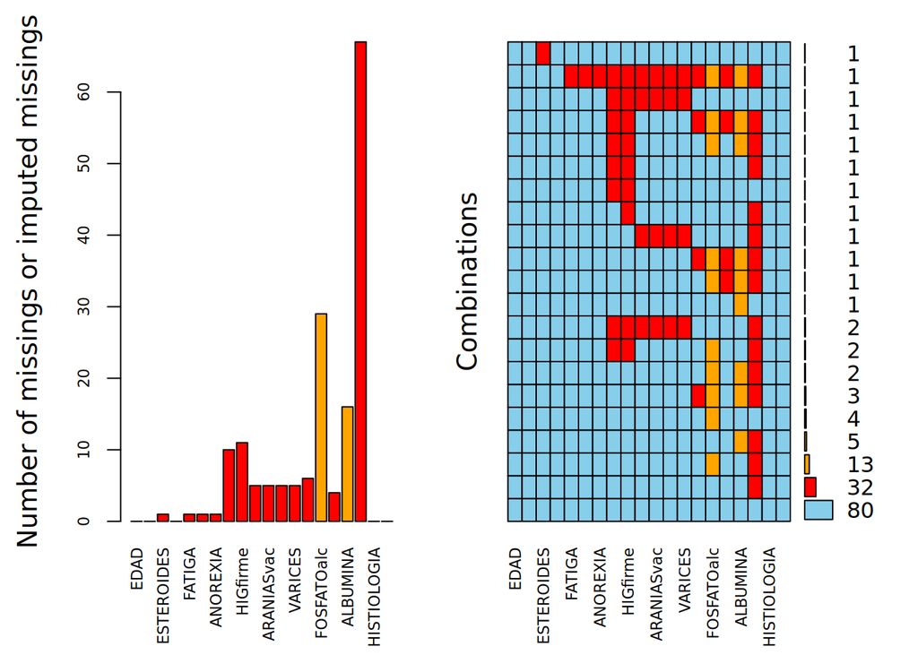

```r
hepatitis.knn <- kNN(hepatitis, variable = c("FOSFATOalc", "ALBUMINA"))
aggr(hepatitis.knn, delimiter = "_imp", numbers = TRUE, prop = FALSE, cex.axis = 0.7)
```

Por defecto, si no se dice qué variables se van a imputar, se imputan todas las variables con valores ausentes. El paquete `VIM` también incluye otros métodos de imputación, además de muchas funciones para analizar gráficamente la distribución de los valores ausentes:

| Función | Métodod |
| --- | --- |
| `hotdeck()` | Hot-deck Imputation |
| `irmi()` | Iterative Robust Model-based Imputation |
| `regressionImp()` | Individual Regression Imputation |
| `rangerImpute()` | Random Forest Imputation |

**Ejercicio 6:**

¿Cómo podemos saber qué valores han sido imputados?

## 6.2 El paquete `Hmisc`

El paquete `Hmisc` nos ofrece la función `impute(x,fun)` donde:

| Parámetro | Descripción |
| --- | --- |
| `x` | Array con valores ausentes a imputar |
| `fun` | Función de imputación: `random`, `median`,`mean` |

Por defecto se utiliza la mediana, pero también existe la posibilidad de pasar un valor o un vector al parámetro `fun` para suministrar valores concretos con los que imputar. En el caso de vectores de tipo `factor` se utiliza el valor más frecuente. Una ventaja de esta función es que marca los valores imputados, de tal forma que, con la función `is.impute()`, podemos saber si el valor ha sido imputado o no. Por ejemplo, para imputar los valores ausentes en el atributo `FOSFATOalc` con el valor medio hay que realizar las siguientes operaciones:

```r
library(Hmisc)
hepatitis.mean <- hepatitis
hepatitis.mean$FOSFATOalc <- impute(hepatitis.mean$FOSFATOalc, fun = mean)
hepatitis.mean$ALBUMINA <- impute(hepatitis.mean$ALBUMINA, fun = mean)
print(hepatitis.mean$FOSFATOalc)
```

```
##   [1]  85.0000  135.0000   96.0000   46.0000  105.3254*  95.0000  105.3254*
##   [8] 105.3254* 105.3254* 105.3254*  78.0000   59.0000   81.0000   57.0000
##  [15] 105.3254*  72.0000  102.0000   62.0000   53.0000   70.0000   48.0000
##  [22] 133.0000   85.0000   60.0000   45.0000   95.0000   85.0000  175.0000
##  [29]  78.0000   78.0000  280.0000  105.3254*  81.0000  135.0000   58.0000
##  [36]  67.0000  194.0000  150.0000   85.0000  180.0000   75.0000   56.0000
##  [43]  46.0000   71.0000  105.3254*  74.0000   80.0000  191.0000   85.0000
##  [50] 125.0000   85.0000   85.0000  110.0000   85.0000   50.0000   92.0000
##  [57] 105.3254*  52.0000   80.0000   85.0000   26.0000  102.0000  215.0000
##  [64] 164.0000  103.0000  105.3254*  62.0000  105.3254*  34.0000   68.0000
##  [71]  82.0000  127.0000   76.0000  105.3254* 100.0000   55.0000  167.0000
##  [78]  30.0000   72.0000   85.0000  105.3254*  62.0000  100.0000  179.0000
##  [85] 141.0000   44.0000  135.0000  165.0000  118.0000   76.0000  230.0000
##  [92] 105.3254* 105.3254* 105.3254* 107.0000   40.0000  147.0000  114.0000
##  [99]  84.0000  105.3254* 123.0000  105.3254* 168.0000  215.0000   86.0000
## [106] 105.3254* 138.0000  105.3254* 155.0000   63.0000  256.0000   62.0000
## [113]  85.0000   81.0000  141.0000  119.0000  105.3254* 139.0000  105.3254*
## [120]  85.0000   90.0000  160.0000   85.0000  105.3254*  85.0000   70.0000
## [127] 105.3254* 155.0000   85.0000   82.0000   85.0000  105.3254* 158.0000
## [134] 115.0000  243.0000  181.0000  105.3254* 130.0000  166.0000   85.0000
## [141] 295.0000  120.0000  105.3254*  85.0000  105.3254*  75.0000   65.0000
## [148] 109.0000   89.0000  120.0000  105.3254* 126.0000   75.0000   81.0000
## [155] 100.0000
```

**Ejercicio 7:**

1. Imputa la variable `ALBUMINA` utilizando la media.
2. ¿Cómo podríamos visualizar dichos imputaciones utilzando la función `aggr()`?

## 6.3 El paquete `mice`

La librería `misc` nos ofrece la función `mice()`, que nos permite imputar los valores ausentes de todo el conjunto de datos al mismo tiempo, considerando, además de los valores de la propia columna, tiene en cuenta los valores del resto de columnas. Esta función crea un modelo distinto para cada variable. Esta función, nos ofrece multitud de métodos los cuales dependen del tipo de variables en el conjunto de datos (para ver la lista de métodos disponibles se puede ejecutar `methods(mice)`. Como ejemplo, para aplicar el método **Predictive Mean Matching** ejecutaríamos las siguientes instrucciones:

```r
library(mice)
tempImp.mice <- mice(hepatitis, m = 5, method = "pmm", seed = 500)
```

El parámetro `m` indica el número de conjunto de datos imputados que se generan. Para ello se utilizan el *muestreo de Gibbs*. Para analizar el resultado de la imputación en la variable `ALBUMINA` hay que utilizar la siguiente instrucción:

```r
tempImp.mice$imp$ALBUMINA
```

```
##       1   2   3   4   5
## 7   2.9 4.5 2.7 3.3 3.3
## 8   4.2 4.2 4.9 3.9 4.4
## 15  4.0 3.9 4.2 4.2 3.8
## 32  2.7 3.3 3.4 3.1 3.4
## 45  4.2 4.3 4.5 4.0 4.6
## 56  4.2 3.8 3.5 4.0 4.4
## 57  3.3 4.0 3.5 3.3 4.3
## 60  3.1 3.8 3.1 3.8 3.0
## 72  3.8 3.4 2.9 3.0 3.0
## 87  3.0 3.0 3.9 3.8 3.6
## 100 2.7 4.0 3.3 3.0 4.0
## 102 4.2 4.9 4.4 6.4 4.0
## 108 3.6 3.0 3.5 3.0 3.6
## 116 3.4 3.4 4.3 3.0 3.4
## 119 3.8 3.8 4.5 3.4 3.1
## 123 3.9 4.0 4.6 3.9 4.0
```

Para ver los métodos de imputación utilizados en cada columna se puede analizar el atributo `method` del objeto devuelto por la función `mice()`. En nuestro caso, nos indicará que siempre se ha aplicado el método `pmm`. Si no hubiéramos indicado el método de imputación, por defecto se aplican los siguientes métodos:

| Método | Tipo de dato | Descripción |
| --- | --- | --- |
| `pmm` | Cualquiera | Predictive mean matching (método preferido por defecto) |
| `logreg` | Binario | Logistic regresion |
| `polyreg` | Ordinales | Polytomous logistic regresion |
| `plor` | Nominales | Proportional odds model |

Esto nos muestra que valor ha sido imputado en cada fila, para cada una de los 5 conjuntos de datos generados (parámetro `m`$=5$). Para hacer efectiva la imputación en el conjunto de datos original hay que utilizar la función `complete()`:

```r
hepatitis.imp2 <- complete(tempImp.mice, 1)
```

Esta función crea un dataset con los datos imputados utilizando el primero de los conjuntos que han sido generados por la función `mice()`. Si queremos utilizar otro conjunto sólo hay que indicarlo cambiando el 1 por el conjunto que queramos.

**Ejercicio 8:**

1. ¿Cómo imprimirías por pantalla el porcentaje de `NA` de cada columna? Una vez realizada esta operación, genera algunas gráficas con las funciones del paquete `VIM` que permitan visualizar la distribución de los valores ausentes.
2. Utiliza la función `impute()` para imputar los valores ausentes en los atributos SGOT y FOSFATOalc. Utiliza los métodos `median` y `mean` y analiza los resultados ¿Qué cambios aprecias en el conjunto de datos?
3. Compara los resultados con los que se obtendrían con la función `mice()` y el método `pmm` y la imputación con la función `kNN`.
4. Genera cuatro ficheros con los resultados obtenidos con los siguientes nombres `hepatitis.medianImpute.csv`, `hepatitis.meanImpute.csv`, `hepatitis. pmmImpute.csv` y `hepatitis.kNNImpute.csv`. Dichos ficheros sólo deben contener la información relevante para iniciar las tareas de minería de datos.

# 7 Clases desbalanceadas

En este apartado vamos a analizar cómo aplicar técnicas de muestreo para equilibrar el número de instancias entre las distintas clases en un problema con clases desbalanceadas. Vamos aplicar las técnicas analizadas en clase: submuestreo (down-sampling), sobremuestreo (up-sumpling), SMOTE y ROSE.

Primero vamos a analizar las técnicas ofrecias por el paquete `caret` a través de las funciones `downSample()` y `upSample()`. Estás funciones son muy fáciles de utilizar y sólo requieren dos parámetros:

- **`x`** la matriz con las variables predictoras.
- **`y`** un vector de tipo factor con la información sobre la pertenencia de clases.
- ** list ** por defecto `FALSE` indicando que se devolverá un dataframe con los predictores y la clase.
- **`yname`** nombre que debe tener la columna con la información de la clase (por defecto tendrá “Class”)

Por ejemplo, en caso de un sobre muestro deberíamos realizar la operación:

```r
library(caret)
set.seed(123)
hepatitis.upSample <- upSample(
  x = hepatitis[, -ncol(hepatitis)],
  y = hepatitis$PRONOSTICO,
  yname = "PRONOSTICO"
)
```

Comparando los resultados podemos comprobar el efecto.

```r
table(hepatitis$PRONOSTICO)
```

```
##
## FALLECE    VIVE
##      32     123
```

```r
table(hepatitis.upSample$PRONOSTICO)
```

```
##
## FALLECE    VIVE
##     123     123
```

```r
library(dplyr)


hepatitis_factor <- hepatitis.imp2 %>%
  mutate_if(is.factor, as.integer) %>%
  mutate_if(is.logical, as.integer)
```

Un vez convertidos a numéricos ya podemos aplicar la función `SMOTE()` del paquete `smotefalimily`, en la que el parámetro `dup_size` nos indica el número de veces que se ejecuta el alogirtmo por cada instancia de la clase minoritaria. Con `dup_size = 0` el algoritmo genera el número óptimo de instancias de la clase minoritaria.

```r
library(smotefamily)
set.seed(123)
hepatitis_smote <- SMOTE(hepatitis_factor[, !names(hepatitis_factor) %in% c("PRONOSTICO")], hepatitis$PRONOSTICO, dup_size = 0)

hepatitis_bal <- hepatitis_smote$data %>% rename(PRONOSTICO = class)

table(hepatitis_bal$PRONOSTICO)
```

```
##
## FALLECE    VIVE
##      96     123
```

La función `ROSE()` del paquete tiene dos parámetros que nos permiten controlar el tamaño y distribución de clases del dataset balanceado:

- **N:** que indica el tamaño del dataset que se va a generar
- **p:** la proproción aproximada de instancias de en la clase minoritaria.

```r
library(ROSE)

hepatitis_rose <- ROSE(PRONOSTICO ~ ., data = hepatitis_factor, p = .5, seed = 123)


table(hepatitis_rose$data$PRONOSTICO)
```

```
##
##  1  2
## 73 82
```

**Ejercicio 9:**

1. Genera nuevos conjunto de datos con cada una de las técnicas de muestreo para resolver el problema de desbalanceo de clases.
2. Compara las distribuciones de clases obtenidos con cada una de las técnicas.